# Analyzing the Effects of Depression in Twitter

## 3.1 Exploratory Data Analysis

###Load the Data. Data from [kaggle](https://www.kaggle.com/datasets/infamouscoder/mental-health-social-media).  
Download and upload as `Mental-Health-Twitter.csv` to the folder `data`.  
Using package `data.table` to read and to manipulate data is much faster than using `read.csv()` especially when the dataset is large.

###Subsetting Let’s first take a small piece of it to work through. We could use `fread` to only load `nrows` many rows to avoid loading the entire dataset.

```r
#data.all <- read.csv("yelp_subset.csv", as.is=TRUE) # as.is = T to keep the texts as character
data.all <- fread("/content/data/Mental_Health_Twitter.csv", stringsAsFactors = FALSE)
dim(data.all)
object.size(data.all)
summary(data.all)
str(data.all)
```

1. 89171
2. 8

```
19251376 bytes



       V1           user_id                     post_text
 Min.   :    0   Min.   :               9457   Length:89171
 1st Qu.:22292   1st Qu.:          469925723   Class :character
 Median :44585   Median : 727014861327093760   Mode  :character
 Mean   :44585   Mean   : 568113714782200812
 3rd Qu.:66878   3rd Qu.:1171262765597712385
 Max.   :89170   Max.   :1338665447697235969
     label          followers          friends         favorites
 Min.   :0.0000   Min.   :      0   Min.   :     0   Min.   :     0
 1st Qu.:0.0000   1st Qu.:    154   1st Qu.:   211   1st Qu.:  3148
 Median :0.0000   Median :    425   Median :   468   Median : 10975
 Mean   :0.4915   Mean   :   5272   Mean   :  1298   Mean   : 27936
 3rd Qu.:1.0000   3rd Qu.:   1289   3rd Qu.:   982   3rd Qu.: 33264
 Max.   :1.0000   Max.   :1429030   Max.   :181822   Max.   :441317
    statuses
 Min.   :     25
 1st Qu.:   2804
 Median :   8972
 Mean   :  25584
 3rd Qu.:  25741
 Max.   :1527058


Classes ‘data.table’ and 'data.frame':  89171 obs. of  8 variables:
 $ V1       : int  0 1 2 3 4 5 6 7 8 9 ...
 $ user_id  :integer64 1249839468 1249839468 1249839468 1249839468 1249839468 1249839468 1249839468 1249839468 ...
 $ post_text: chr  "@kristenevanss14 retweet again 🙃🙃🙃" "Wish I could be with my family and it not be in Zavalla bc this town literally makes me sick to my stomach" "@kaileinicole10 This is so true 😩" "Dalton and I started our trip with the best hike ❤️ https://t.co/h5IkRTEArB" ...
 $ label    : int  0 0 0 0 0 0 0 0 0 0 ...
 $ followers: num  378 378 378 378 378 378 378 378 378 378 ...
 $ friends  : num  151 151 151 151 151 151 151 151 151 151 ...
 $ favorites: num  1350 1350 1350 1350 1350 1350 1350 1350 1350 1350 ...
 $ statuses : num  7207 7207 7207 7207 7207 ...
 - attr(*, ".internal.selfref")=<externalptr>
```

```r
data.subset <- data.all
```

###EDA & Sentiment Analysis

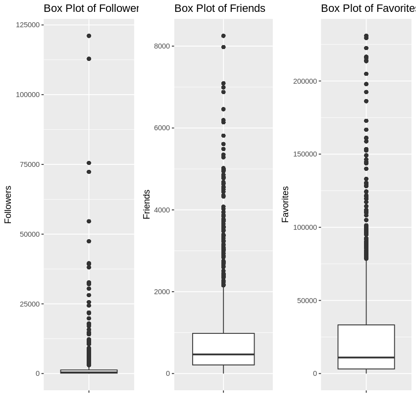

png

```r
#@title Plot a box plot for all quantitative predictors
# Box plot for followers
p1 <- ggplot(data.subset, aes(x = "", y = followers)) +
    coord_cartesian(ylim = c(0, quantile(data.subset$followers, 0.99))) +
    geom_boxplot() +
    labs(title = "Box Plot of Followers",
         x = "",
         y = "Followers") #+ scale_y_log10()

# Box plot for friends
p2 <- ggplot(data.subset, aes(x = "", y = friends)) +
    coord_cartesian(ylim = c(0, quantile(data.subset$friends, 0.99))) +
    geom_boxplot() +
    labs(title = "Box Plot of Friends",
         x = "",
         y = "Friends") #+ scale_y_log10()

# Box plot for favourites
p3 <- ggplot(data.subset, aes(x = "", y = favorites)) +
    coord_cartesian(ylim = c(0, quantile(data.subset$favorites, 0.99))) +
    geom_boxplot() +
    labs(title = "Box Plot of Favorites",
         x = "",
         y = "Favorites") # + scale_y_log10()

# Display the plots
grid.arrange(p1, p2, p3, ncol = 3)
```

```r
#@title Sentiment Analysis with Vader
data.subset <- data.subset %>%
  mutate(sentiment_score = vader_df(post_text)$compound)
#@title Incorporate Sentiment into Dataset
average_scores <- data.subset %>%
  group_by(user_id) %>%
  summarize(sentiment_score_average = mean(sentiment_score, na.rm = TRUE))

# Join the average sentiment scores back to the original dataset
data.subset <- data.subset %>%
  left_join(average_scores, by = "user_id")
data.all <- data.subset
```

```r
data.subset <- read.csv("sentiment_analysis.csv")
```

```r
data.quant = data.subset[,c("label", "followers", "friends", "favorites", "statuses", "sentiment_score_average")]
dim(data.quant)
```

1. 89171
2. 6

```r
data.quant <- distinct(data.quant)
dim(data.quant)
```

1. 1123
2. 6

```r
colnames(data.quant)
```

1. ‘label’
2. ‘followers’
3. ‘friends’
4. ‘favorites’
5. ‘statuses’
6. ‘sentiment_score_average’

```r
data.quant$log_followers <- log(data.quant$followers+1)
```

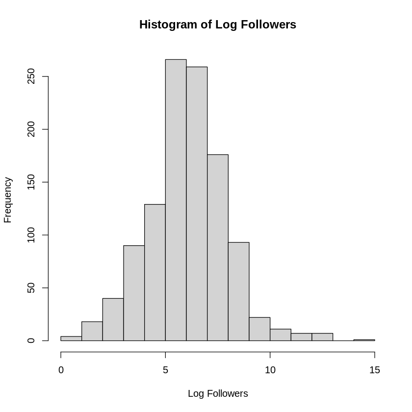

png

```r
hist(data.quant$log_followers, xlab="Log Followers", main="Histogram of Log Followers")
```

```r
data.quant$log_friends <- log(data.quant$friends+1)
```

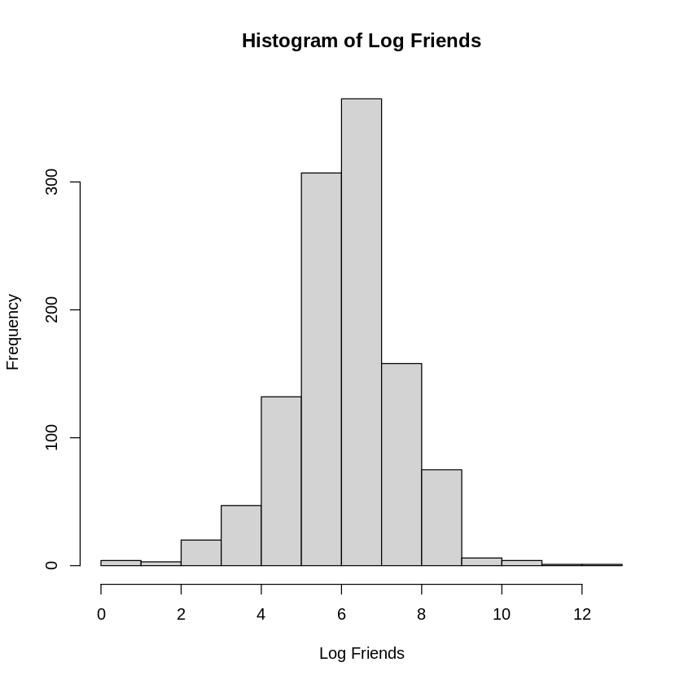

png

```r
hist(data.quant$log_friends, xlab="Log Friends", main="Histogram of Log Friends")
```

```r
data.quant$log_favorites <- log(data.quant$favorites+1)
```

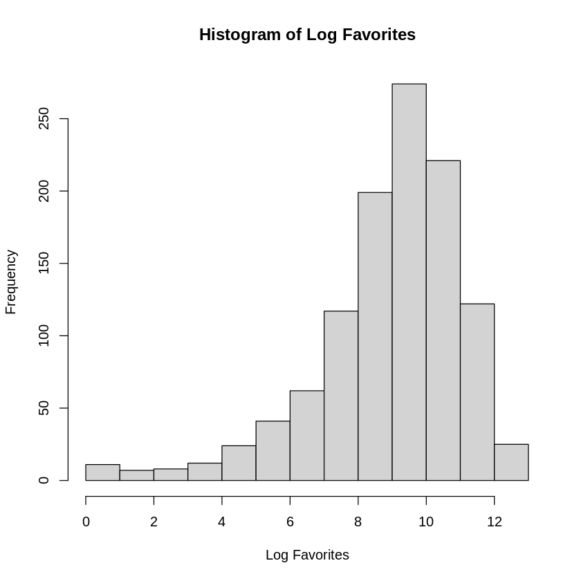

png

```r
hist(data.quant$log_favorites, xlab="Log Favorites", main="Histogram of Log Favorites")
```

##Analysis of Variables

```r
dim(data.quant)
```

1. 1123
2. 9

```r
#@title Splitting the Dataset
# taking a subset of twitter data
# We could use fread with a specified nrows. We might need to shuffle the data in order to get a random sample.
set.seed(1)
test_indices <- sample(nrow(data.quant), 0.2*nrow(data.quant))
data.subset <- data.quant[-test_indices,]
data.testset <- data.quant[test_indices,]
# Take a small set to work through
# MAKE SURE: you will rerun the analyses later by setting back a larger dataset.
table(data.subset$label)
table(data.testset$label)
# dim(data.subset)
# dim(data.testset)
```

```
  0   1
456 443




  0   1
114 110
```

```r
#@title Fit a linear model
data.subz <- data.subset %>%
  mutate(followers = as.numeric(followers/10000),
  friends = as.numeric(friends/10000),
  favorites = as.numeric(favorites/10000))

fit_lm <- lm(label ~ log_followers + log_friends + log_favorites + sentiment_score_average, data = data.subset)
stargazer(fit_lm, type="text")

# fit_lm_1000 <- lm(label ~ log_followers + log_friends + log_favorites + sentiment_score_average, data = data.subz)
# stargazer(fit_lm_1000, type="text")


# fit_standardized <- lm.beta(fit_lm)
# stargazer(fit_standardized, type="text")
```

```
===================================================
                            Dependent variable:
                        ---------------------------
                                   label
---------------------------------------------------
log_followers                    -0.038***
                                  (0.012)

log_friends                       -0.021
                                  (0.017)

log_favorites                    0.047***
                                  (0.009)

sentiment_score_average           -0.083
                                  (0.141)

Constant                         0.439***
                                  (0.083)

---------------------------------------------------
Observations                        899
R2                                 0.041
Adjusted R2                        0.037
Residual Std. Error          0.491 (df = 894)
F Statistic               9.608*** (df = 4; 894)
===================================================
Note:                   *p<0.1; **p<0.05; ***p<0.01
```

```r
#@title Fit Logistic Regression Model

# Fit logistic regression model with log-transformed variables
fit_logistic <- glm(label ~ log_followers + log_friends + log_favorites + sentiment_score_average,
                    data = data.subset,
                    family = binomial(logit))

# Summarize the logistic regression model using stargazer
stargazer(fit_logistic, type = "text")

# Summarize the logistic regression model using summary
summary(fit_logistic)
```

```
===================================================
                            Dependent variable:
                        ---------------------------
                                   label
---------------------------------------------------
log_followers                    -0.173***
                                  (0.053)

log_friends                       -0.085
                                  (0.074)

log_favorites                    0.207***
                                  (0.041)

sentiment_score_average           -0.352
                                  (0.595)

Constant                          -0.287
                                  (0.357)

---------------------------------------------------
Observations                        899
Log Likelihood                   -603.533
Akaike Inf. Crit.                1,217.066
===================================================
Note:                   *p<0.1; **p<0.05; ***p<0.01




Call:
glm(formula = label ~ log_followers + log_friends + log_favorites +
    sentiment_score_average, family = binomial(logit), data = data.subset)

Coefficients:
                        Estimate Std. Error z value Pr(>|z|)
(Intercept)             -0.28710    0.35732  -0.803  0.42169
log_followers           -0.17309    0.05276  -3.281  0.00103 **
log_friends             -0.08526    0.07355  -1.159  0.24640
log_favorites            0.20687    0.04090   5.058 4.24e-07 ***
sentiment_score_average -0.35245    0.59473  -0.593  0.55343
---
Signif. codes:  0 ‘***’ 0.001 ‘**’ 0.01 ‘*’ 0.05 ‘.’ 0.1 ‘ ’ 1

(Dispersion parameter for binomial family taken to be 1)

    Null deviance: 1246.1  on 898  degrees of freedom
Residual deviance: 1207.1  on 894  degrees of freedom
AIC: 1217.1

Number of Fisher Scoring iterations: 4
```

```r
#@title Decision Tree
# Fit the decision tree model
fit_tree1 <- rpart(label ~ followers + friends + favorites + sentiment_score_average,
                   data = data.subset,
                   control = rpart.control(minsplit = 2))

output_file <- "/content/decision_tree_plot.png"

# Save the plot to a PNG file
png(filename = output_file, width = 800, height = 600)

# Plot the decision tree with customizations
rpart.plot(fit_tree1,
           type = 2,           # Type of plot: 0, 1, 2, 3, 4 (3 is compact)
           extra = 101,        # Display number of observations that follow the path and percentage
           under = TRUE,       # Put the split variable name under the box
           faclen = 0,         # Factor levels as full names
           tweak = 1.3,        # Scale text and boxes
           fallen.leaves = TRUE)  # Put leaves at the bottom of the plot

dev.off()
```

**png:** 2

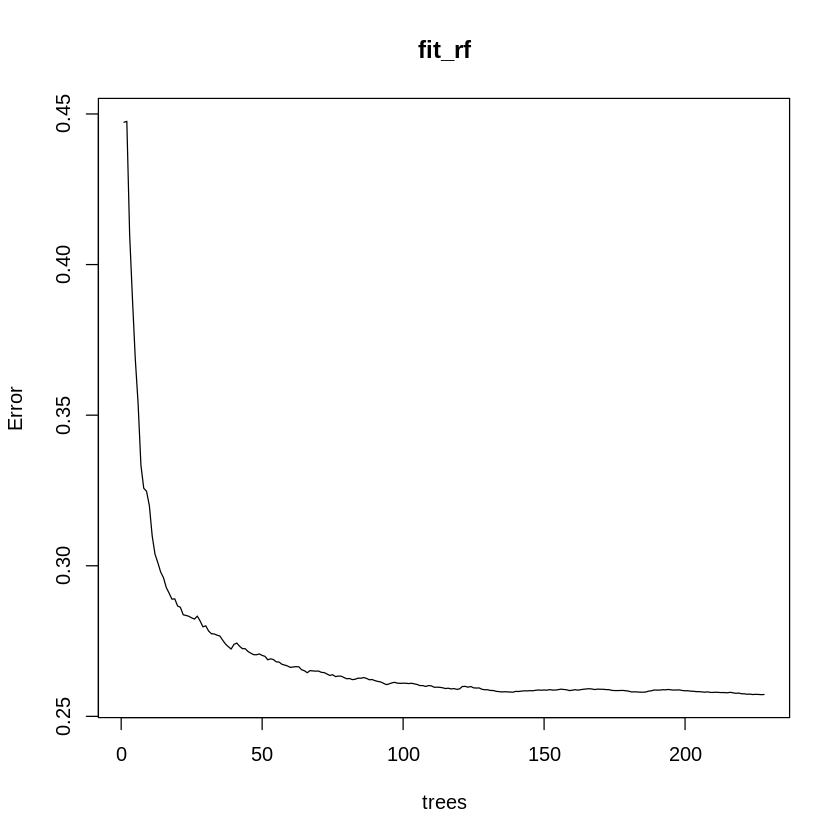

png

```r
#@title Random Forest
# Load necessary libraries
# set.seed(100)#21, 60
# Fit the random forest model
fit_rf <- randomForest(label ~ followers + friends + favorites + sentiment_score_average,
                       data = data.subset,
                       mtry = 2,
                       ntree = 228,
                       importance = TRUE)

# Print the detailed summary of the model
# print(fit_rf)

# summary(fit_rf)
# stargazer(fit_rf, type="text")
plot(fit_rf)

# Optional: Confusion matrix to evaluate the model
# confusion_matrix <- confusionMatrix(predict(fit_rf, data.subset), data.subset$label)
# print(confusion_matrix)
```

```r
#@title Comparing Models
lm_preds <- predict(fit_lm, data.testset, type="response")
lm_preds <- ifelse(lm_preds > 0.5, 1, 0)
logistic_preds <- predict(fit_logistic, data.testset, type="response")
logistic_preds <- ifelse(logistic_preds > 0.5, 1, 0)
tree_preds <- predict(fit_tree1, data.testset[,c("followers", "friends", "favorites", "sentiment_score_average")])
tree_preds <- ifelse(tree_preds > 0.5, 1, 0)
rf_preds <- predict(fit_rf, data.testset, type="class")
rf_preds <- ifelse(rf_preds > 0.5, 1, 0)

lm_accuracy <- mean(lm_preds==data.testset$label)
logistic_accuracy <- mean(logistic_preds==data.testset$label)
tree_accuracy <- mean(tree_preds==data.testset$label)
rf_accuracy <- mean(rf_preds==data.testset$label)

data.frame(
  Model = c("Linear Model", "Logistic Regression", "Decision Tree", "Random Forest"),
  Accuracy = c(lm_accuracy, logistic_accuracy, tree_accuracy, rf_accuracy)
)
```

A data.frame: 4 × 2

| Model <chr> | Accuracy <dbl> |
| --- | --- |
| Linear Model | 0.5982143 |
| Logistic Regression | 0.5892857 |
| Decision Tree | 0.5223214 |
| Random Forest | 0.6026786 |

#Text Analysis: Kaggle Dataset

## 3.2 Bag of Words & Term Frequency

###Corpus: a collection of text  
- `VCorpus()`: create Volatile Corpus  
- `inspect()`: display detailed info of a corpus

```r
mycorpus1 <- VCorpus(VectorSource(data.subset$post_text))
mycorpus1
typeof(mycorpus1)   ## It is a list
# inspect the first corpus
inspect(mycorpus1[[1]])
# or use `as.character` to extract the text
as.character(mycorpus1[[1]])
```

[output not shown]

‘list’

```
<<PlainTextDocument>>
Metadata:  7
Content:  chars: 140

It's just over 2 years since I was diagnosed with #anxiety and #depression. Today I'm taking a moment to reflect on how far I've come since.
```

‘It's just over 2 years since I was diagnosed with #anxiety and #depression. Today I'm taking a moment to reflect on how far I've come since.’

###Data cleaning using `tm_map()`

```r
# Converts all words to lowercase
mycorpus_clean <- tm_map(mycorpus1, content_transformer(tolower))

# Removes common English stopwords (e.g. "with", "i")
mycorpus_clean <- tm_map(mycorpus_clean, removeWords, stopwords("english"))

# Removes any punctuation
# NOTE: This step may not be appropriate if you want to account for differences
#       on semantics depending on which sentence a word belongs to if you end up
#       using n-grams or k-skip-n-grams.
#       Instead, periods (or semicolons, etc.) can be replaced with a unique
#       token (e.g. "[PERIOD]") that retains this semantic meaning.
mycorpus_clean <- tm_map(mycorpus_clean, removePunctuation)

# Removes numbers
mycorpus_clean <- tm_map(mycorpus_clean, removeNumbers)

# Stem words
mycorpus_clean <- tm_map(mycorpus_clean, stemDocument, lazy = TRUE)
```

###Word frequency matrix

Now we transform each review into a word frequency matrix using the function `DocumentTermMatrix()`.

```r
dtm1 <- DocumentTermMatrix( mycorpus_clean )   ## library = collection of words for all documents
class(dtm1)
inspect(dtm1) # typeof(dtm1)  #length(dimnames(dtm1)$Terms)
```

1. ‘DocumentTermMatrix’
2. ‘simple_triplet_matrix’

```
<<DocumentTermMatrix (documents: 16288, terms: 22534)>>
Non-/sparse entries: 109270/366924522
Sparsity           : 100%
Maximal term length: 73
Weighting          : term frequency (tf)
Sample             :
       Terms
Docs    can depress get just know like love now one thank
  10470   0       0   0    0    0    0    0   0   0     0
  10475   0       0   0    0    0    0    0   0   0     0
  13134   0       0   0    0    0    0    0   1   0     0
  4191    0       0   0    0    0    0    0   0   0     0
  4249    0       0   0    1    0    0    0   0   0     0
  4366    0       0   0    0    0    0    0   0   0     0
  4501    0       0   0    0    0    0    0   0   0     0
  6750    0       0   0    0    1    0    0   0   0     0
  7571    0       0   0    0    0    1    0   0   0     0
  7972    0       0   0    0    0    1    0   0   0     0
```

### 3.2.1 Reduce the size of the bag

Many words do not appear nearly as often as others. If your cleaning was done appropriately, it will hopefully not lose much of the information if we drop such rare words. So, we first cut the bag to only include the words appearing at least 1% (or the frequency of your choice) of the time. This reduces the dimension of the features extracted to be analyzed.

```r
threshold <- .01*length(mycorpus_clean)   # 1% of the total documents
words.10 <- findFreqTerms(dtm1, lowfreq=threshold)  # words appearing at least among 1% of the documents
length(words.10)
tail(words.10, n=10)
```

81

1. ‘use’
2. ‘via’
3. ‘wait’
4. ‘want’
5. ‘watch’
6. ‘way’
7. ‘well’
8. ‘will’
9. ‘work’
10. ‘year’

```r
dtm.10<- DocumentTermMatrix(mycorpus_clean, control = list(dictionary = words.10))
dim(as.matrix(dtm.10))
colnames(dtm.10)[40:50]
```

1. 16288
2. 81
1. ‘never’
2. ‘new’
3. ‘now’
4. ‘one’
5. ‘overcom’
6. ‘peopl’
7. ‘person’
8. ‘pleas’
9. ‘realdonaldtrump’
10. ‘realli’
11. ‘right’

**`removeSparseTerms()`**:

Anther way to reduce the size of the bag is to use `removeSparseTerms`

```r
dtm.10.2 <- removeSparseTerms(dtm1, 1-.01)  # control sparsity < .99
inspect(dtm.10.2)
# colnames(dtm.10.2)[1:50]
# words that are in dtm.10 but not in dtm.10.2
colnames(dtm.10)[!(colnames(dtm.10) %in% colnames(dtm.10.2))]
```

```
<<DocumentTermMatrix (documents: 16288, terms: 74)>>
Non-/sparse entries: 22745/1182567
Sparsity           : 98%
Maximal term length: 15
Weighting          : term frequency (tf)
Sample             :
       Terms
Docs    can depress get just know like love now one thank
  12418   1       0   0    0    0    0    0   0   0     0
  1408    0       1   0    0    0    0    1   0   1     0
  5104    0       0   1    0    0    2    0   0   1     0
  6147    0       0   0    0    0    1    0   0   0     0
  7142    1       0   2    1    0    0    0   0   2     0
  7933    0       0   0    0    1    0    0   0   0     0
  8316    0       0   0    0    0    0    1   0   0     0
  932     1       0   0    0    1    0    0   0   0     0
  955     0       0   1    2    1    0    1   0   2     0
  9608    0       0   2    1    0    0    0   0   0     0
```

1. ‘guy’
2. ‘migrain’
3. ‘person’
4. ‘pleas’
5. ‘shit’
6. ‘sleep’
7. ‘tweet’

We end up with two different bags because

- `findFreqTerms()`: counts a word multiple times if it appears multiple times in one document.
- `removeSparseTerms()`: keep words that appear at least once in X% of documents.

### 3.2.2 One step to get `DTM`

We consolidate all possible processing steps to the following clean `R-chunk`, turning texts (input) into `Document Term Frequency` which is a sparse matrix (output) to be used in the down-stream analyses.

All the `tm_map()` can be called inside `DocumentTermMatrix` under parameter called `control`. Here is how.

```r
# Turn texts to corpus
mycorpus1  <- VCorpus(VectorSource(data.subset$post_text))


# Control list for creating our DTM within DocumentTermMatrix
# Can tweak settings based off if you want punctuation, numbers, etc.
control_list <- list( tolower = TRUE,
                      removePunctuation = TRUE,
                      removeNumbers = TRUE,
                      stopwords = stopwords("english"),
                      stemming = TRUE)
# dtm with all terms:
dtm.10.long  <- DocumentTermMatrix(mycorpus1, control = control_list)
#inspect(dtm.10.long)

# kick out rare words
dtm.10<- removeSparseTerms(dtm.10.long, 1-.01)
inspect(dtm.10)

# look at the document 1 before and after cleaning
# inspect(mycorpus1[[1]])
# after cleaning
# colnames(as.matrix(dtm1[1, ]))[which(as.matrix(dtm1[1, ]) != 0)]
```

```
<<DocumentTermMatrix (documents: 16288, terms: 81)>>
Non-/sparse entries: 24779/1294549
Sparsity           : 98%
Maximal term length: 15
Weighting          : term frequency (tf)
Sample             :
       Terms
Docs    can depress dont get just know like now one thank
  12418   1       0    0   0    0    0    0   0   0     0
  1408    0       1    0   0    0    0    0   0   1     0
  3171    0       0    1   0    1    0    0   0   0     0
  6147    0       0    0   0    0    0    1   0   0     0
  7142    1       0    0   2    1    0    0   0   2     0
  7933    0       0    1   0    0    1    0   0   0     0
  8455    0       0    1   0    0    0    0   0   0     0
  932     1       0    1   0    0    1    0   0   0     0
  955     0       0    1   1    2    1    0   0   2     0
  9608    0       0    1   2    1    0    0   0   0     0
```

## 3.3 N-grams

Using the `tm` package along with a custom tokenizer, we can now implement n-grams using R! As is, the tokenizer is set to produce bugrams but you should be able to change this by tweaking the variable `n`.

```r
# The 'n' for n-grams
# n=2 is bi-grams
n <- 2

# Our custom tokenizer
# Uses the ngrams function from the NLP package
# Right now this is for bigrams, but you can change it by changing the value of
# the variable n (includes N-grams for any N <= n)
ngram_tokenizer <- function(x, n) {
  unlist(lapply(ngrams(words(x), 1:n), paste, collapse = "_"), use.names = FALSE)
}
```

We next prepare a clean corpus

```r
# Converts all words to lowercase
mycorpus1  <- VCorpus(VectorSource(data.subset$post_text))
mycorpus_clean <- tm_map(mycorpus1, content_transformer(tolower))

# Removes common English stopwords (e.g. "with", "i")
mycorpus_clean <- tm_map(mycorpus_clean, removeWords, stopwords("english"))

# Removes any punctuation
# NOTE: This step may not be appropriate if you want to account for differences
#       on semantics depending on which sentence a word belongs to if you end up
#       using n-grams or k-skip-n-grams.
#       Instead, periods (or semicolons, etc.) can be replaced with a unique
#       token (e.g. "[PERIOD]") that retains this semantic meaning.
mycorpus_clean <- tm_map(mycorpus_clean, removePunctuation)

# Removes numbers
mycorpus_clean <- tm_map(mycorpus_clean, removeNumbers)

# Stem words
mycorpus_clean <- tm_map(mycorpus_clean, stemDocument, lazy = TRUE)
```

Apply the bigram tokenizer to the first review, we see the library or word of bag is enlarged.

```r
inspect(mycorpus_clean[[1]])  # see review 1 again
ngram_tokenizer(mycorpus_clean[[1]], 2) # output bigram of review 1
```

```
<<PlainTextDocument>>
Metadata:  7
Content:  chars: 78

just year sinc diagnos anxieti depress today take moment reflect far come sinc
```

1. ‘just’
2. ‘year’
3. ‘sinc’
4. ‘diagnos’
5. ‘anxieti’
6. ‘depress’
7. ‘today’
8. ‘take’
9. ‘moment’
10. ‘reflect’
11. ‘far’
12. ‘come’
13. ‘sinc’
14. ‘just_year’
15. ‘year_sinc’
16. ‘sinc_diagnos’
17. ‘diagnos_anxieti’
18. ‘anxieti_depress’
19. ‘depress_today’
20. ‘today_take’
21. ‘take_moment’
22. ‘moment_reflect’
23. ‘reflect_far’
24. ‘far_come’
25. ‘come_sinc’

While we won’t run any analyses with the n-grams, we encourage you to play around with some of the settings to see how the DTM changes, as well as how the analysis might be improved (or worsened) by including the higher order n-grams.

```r
# use ngram_tokenizer()
control_list_ngram <- list(tokenize = function(x) ngram_tokenizer(x, 2))

dtm_ngram <- DocumentTermMatrix(mycorpus_clean, control_list_ngram)
# kick out rare words
dtm_ngram.10 <- removeSparseTerms(dtm_ngram, 1-.01)
inspect(dtm_ngram.10)
```

```
<<DocumentTermMatrix (documents: 16288, terms: 80)>>
Non-/sparse entries: 24004/1279036
Sparsity           : 98%
Maximal term length: 17
Weighting          : term frequency (tf)
Sample             :
       Terms
Docs    can depress get just know like love now one thank
  12418   1       0   0    0    0    0    0   0   0     0
  1408    0       1   0    0    0    0    1   0   1     0
  14336   0       0   0    0    0    0    0   1   0     1
  14337   0       0   0    0    0    0    0   1   0     1
  14351   0       0   0    0    0    0    0   1   0     1
  14496   0       0   0    2    0    0    0   1   0     1
  14498   0       0   0    2    0    0    0   1   0     1
  7142    1       0   2    1    0    0    0   0   2     0
  7933    0       0   0    0    1    0    0   0   0     0
  955     0       0   1    2    1    0    1   0   2     0
```

##Analysis

Once we have turned a text into a vector, we can then apply any methods suitable for the settings. In our case we will use logistic regression models and LASSO to explore the relationship between `label` and `text`.

### 3.3.1 Data preparation

The following chunk output a data frame called data2, combining everything and all the tf’s of each word.

```r
names(data.subset)
# Combine the original data with the text matrix
data1.temp <- data.frame(data.subset,as.matrix(dtm_ngram.10) )
dim(data1.temp)
names(data1.temp)[1:30]
#str(data1.temp)
# data2 consists of date, label and all the top 1% words
data2 <- data1.temp[, c(7:ncol(data1.temp))]
#data2 <- data1.temp
names(data2)[1:20]
dim(data2)  ### remember we have only run 1000 rows

#### We have previously run the entire 100,000 rows and output the DTM out.
### if not, run and write as csv
fwrite(data2, "/content/data/Twitter_tm_freq.csv", row.names = FALSE)
```

1. ‘V1’
2. ‘post_text’
3. ‘user_id’
4. ‘followers’
5. ‘friends’
6. ‘favorites’
7. ‘statuses’
8. ‘label’
1. 16288
2. 88
1. ‘V1’
2. ‘post_text’
3. ‘user_id’
4. ‘followers’
5. ‘friends’
6. ‘favorites’
7. ‘statuses’
8. ‘label’
9. ‘actual’
10. ‘amp’
11. ‘ask’
12. ‘azarkansero’
13. ‘back’
14. ‘best’
15. ‘can’
16. ‘come’
17. ‘day’
18. ‘depress’
19. ‘depress_treatment’
20. ‘even’
21. ‘feel’
22. ‘follow’
23. ‘follow_twitter’
24. ‘friend’
25. ‘fuck’
26. ‘genevieveverso’
27. ‘get’
28. ‘god’
29. ‘good’
30. ‘got’
1. ‘statuses’
2. ‘label’
3. ‘actual’
4. ‘amp’
5. ‘ask’
6. ‘azarkansero’
7. ‘back’
8. ‘best’
9. ‘can’
10. ‘come’
11. ‘day’
12. ‘depress’
13. ‘depress_treatment’
14. ‘even’
15. ‘feel’
16. ‘follow’
17. ‘follow_twitter’
18. ‘friend’
19. ‘fuck’
20. ‘genevieveverso’
1. 16288
2. 82

### 3.3.2 Splitting data

Let’s first read in the processed data with text being a vector.

```r
data2 <- fread("/content/data/Twitter_tm_freq.csv")  #dim(data2)
names(data2)[1:20] # notice that user_id, stars and date are in the data2
dim(data2)
data2 <- data2 %>% mutate(label=as.factor(label))# %>% select(-"label_numeric")
table(data2$label)
```

1. ‘statuses’
2. ‘label’
3. ‘actual’
4. ‘amp’
5. ‘ask’
6. ‘azarkansero’
7. ‘back’
8. ‘best’
9. ‘can’
10. ‘come’
11. ‘day’
12. ‘depress’
13. ‘depress_treatment’
14. ‘even’
15. ‘feel’
16. ‘follow’
17. ‘follow_twitter’
18. ‘friend’
19. ‘fuck’
20. ‘genevieveverso’
1. 16288
2. 82

```
   0    1
8108 8180
```

As one standard machine learning process, we first split data into two sets one training data and the other testing data. We use training data to build models, choose models etc and make final recommendations. We then report the performance using the testing data.

```r
set.seed(1)  # for the purpose of reporducibility
n <- nrow(data2)
test.index <- sample(n, 0.1*n)
# length(test.index)
data2.test <- data2[test.index, -1] # only keep label and the texts
data2.train <- data2[-test.index, -1]
dim(data2.train)
```

1. 14660
2. 81

### 3.3.3 Analysis 1: LASSO

We first explore a logistic regression model using LASSO. The following R-chunk runs a LASSO model with $\alpha=.99$. The reason we take an elastic net is to enjoy the nice properties from both `LASSO` (impose sparsity) and `Ridge` (computationally stable).

LASSO takes sparse design matrix as an input. So make sure to extract the sparse matrix first as the input in cv.glm(). It takes about 1 minute to run cv.glm() with sparse matrix or 11 minutes using the regular design matrix.

```
   Length     Class      Mode
       59 character character
```

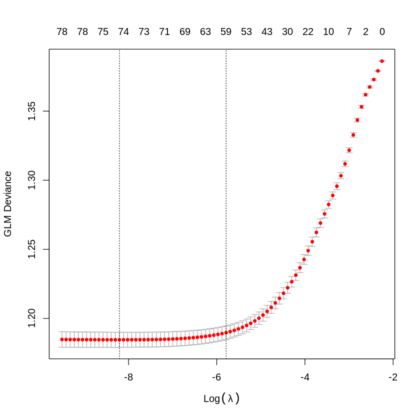

png

```r
### or try `sparse.model.matrix()` which is much faster
y <- data2.train$label
X1 <- sparse.model.matrix(label~., data=data2.train)[, -1]
set.seed(2)
result.lasso <- cv.glmnet(X1, y, alpha=.99, family=binomial(logit))
# 1.25 minutes in my MAC
plot(result.lasso)
# this this may take you long time to run, we save result.lasso
saveRDS(result.lasso, file="data/TextMining_lasso.RDS")
# result.lasso can be assigned back by
# result.lasso <- readRDS("data/TextMining_lasso.RDS")

# number of non-zero words picked up by LASSO when using lambda.1se
# coef.1se <- coef(result.lasso, s="lambda.1se")
# lasso.words <- coef.1se@Dimnames[[1]] [coef.1se@i][-1] # non-zero variables without intercept.
# summary(lasso.words)


# or our old way
coef.1se <- coef(result.lasso, s="lambda.1se")
coef.1se <- coef.1se[which(coef.1se !=0),]
lasso.words <- rownames(as.matrix(coef.1se))[-1]
summary(lasso.words)



### cv.glmnt with the non-sparse design matrix takes much longer
# X <- as.matrix(data2.train[, -1]) # we can use as.matrix directly her
#### Be careful to run the following LASSO.
#set.seed(2)
#result.lasso <- cv.glmnet(X, y, alpha=.99, family="binomial")
# 10 minutes in my MAC
#plot(result.lasso)
```

### 3.3.4 Analysis 2: Relaxed LASSO

```r
sel_cols <- c("label", lasso.words)
# use all_of() to specify we would like to select variables in sel_cols
data_sub <- data2.train %>% select(all_of(sel_cols))
result.glm <- glm(label~., family=binomial, data_sub) # takes 3.5 minutes
## glm() returns a big object with unnecessary information
# saveRDS(result.glm,
#      file = "data/TextMining_glm.RDS")

## trim the glm() fat from
## https://win-vector.com/2014/05/30/trimming-the-fat-from-glm-models-in-r/
stripGlmLR = function(cm) {
  cm$y = c()
  cm$model = c()

  cm$residuals = c()
  cm$fitted.values = c()
  cm$effects = c()
  cm$qr$qr = c()
  cm$linear.predictors = c()
  cm$weights = c()
  cm$prior.weights = c()
  cm$data = c()


  cm$family$variance = c()
  cm$family$dev.resids = c()
  cm$family$aic = c()
  cm$family$validmu = c()
  cm$family$simulate = c()
  attr(cm$terms,".Environment") = c()
  attr(cm$formula,".Environment") = c()

  cm
}

#result.glm.small <- stripGlmLR(result.glm)
result.glm.small <- result.glm

saveRDS(result.glm.small,
     file = "/content/data/TextMining_glm_small.RDS")
View(result.glm.small)
```

```
Call:  glm(formula = label ~ ., family = binomial, data = data_sub)

Coefficients:
    (Intercept)              amp              ask      azarkansero
       -0.20870         -0.15435          0.45942         15.68073
           back             best              can              day
        0.34165         -0.42198          0.06874          0.68845
        depress             feel           friend   genevieveverso
        3.08364          0.71367          0.21416         15.16053
            get              god              got            happi
        0.69338         -0.92267          0.49489          0.26220
           help              hey             hope             just
        0.96364         -1.02911         -0.53614          0.27295
           life             like              lol             look
        0.42904          0.05321          0.53441          0.10717
           love             make              man        misslusyd
        0.27279          0.47850         -0.93853         15.08569
           much             need            never              new
        0.25853          0.09498         -0.24005          0.16968
     now_follow              one          overcom  realdonaldtrump
      -16.91854         -0.30769          1.89115         -5.37890
         realli            right           someon            start
        0.37095         -0.17319          0.29781          0.39808
          still             take             talk            thank
       -0.29167          0.43699          1.31728         -0.44256
          thing            think             time            today
        0.15011          0.55579          0.24965          0.85688
      treatment              tri            trump    twitter_thank
        3.99057          0.41929         -5.12768               NA
            use              via             wait             want
        0.24033          1.19973         -0.19395         -0.18153
          watch              way             will             work
       -0.38245          0.59473         -0.28046          0.16581

Degrees of Freedom: 14659 Total (i.e. Null);  14601 Residual
Null Deviance:      20320
Residual Deviance: 17220    AIC: 17340
```

```r
View(data_sub[1:20])
```

A data.table: 20 × 60

| label <fct> | amp <int> | ask <int> | azarkansero <int> | back <int> | best <int> | can <int> | day <int> | depress <int> | feel <int> | ⋯ | trump <int> | twitter_thank <int> | use <int> | via <int> | wait <int> | want <int> | watch <int> | way <int> | will <int> | work <int> |
| --- | --- | --- | --- | --- | --- | --- | --- | --- | --- | --- | --- | --- | --- | --- | --- | --- | --- | --- | --- | --- |
| 1 | 0 | 0 | 0 | 0 | 0 | 0 | 0 | 1 | 0 | ⋯ | 0 | 0 | 0 | 0 | 0 | 0 | 0 | 0 | 0 | 0 |
| 1 | 0 | 0 | 0 | 0 | 0 | 0 | 0 | 0 | 0 | ⋯ | 0 | 0 | 0 | 0 | 0 | 0 | 0 | 0 | 0 | 0 |
| 1 | 0 | 0 | 0 | 0 | 0 | 0 | 0 | 0 | 0 | ⋯ | 0 | 0 | 0 | 0 | 0 | 0 | 0 | 0 | 0 | 0 |
| 1 | 0 | 0 | 0 | 0 | 0 | 0 | 0 | 0 | 0 | ⋯ | 0 | 0 | 0 | 0 | 0 | 0 | 0 | 0 | 0 | 0 |
| 1 | 0 | 0 | 0 | 0 | 0 | 0 | 0 | 0 | 0 | ⋯ | 0 | 0 | 0 | 0 | 0 | 0 | 0 | 0 | 0 | 0 |
| 1 | 0 | 0 | 0 | 0 | 0 | 0 | 0 | 0 | 0 | ⋯ | 0 | 0 | 0 | 0 | 0 | 0 | 0 | 0 | 0 | 0 |
| 1 | 0 | 0 | 0 | 0 | 0 | 0 | 0 | 0 | 0 | ⋯ | 0 | 0 | 0 | 0 | 0 | 0 | 0 | 0 | 0 | 0 |
| 1 | 0 | 0 | 0 | 0 | 0 | 0 | 0 | 0 | 0 | ⋯ | 0 | 0 | 0 | 0 | 0 | 0 | 0 | 1 | 0 | 0 |
| 1 | 0 | 0 | 0 | 0 | 0 | 0 | 0 | 0 | 0 | ⋯ | 0 | 0 | 0 | 0 | 0 | 0 | 0 | 2 | 0 | 0 |
| 1 | 0 | 0 | 0 | 0 | 0 | 0 | 0 | 0 | 0 | ⋯ | 0 | 0 | 0 | 0 | 0 | 1 | 0 | 0 | 0 | 0 |
| 1 | 0 | 0 | 0 | 0 | 0 | 0 | 0 | 0 | 0 | ⋯ | 0 | 0 | 0 | 0 | 0 | 0 | 0 | 0 | 0 | 0 |
| 1 | 0 | 0 | 0 | 1 | 0 | 0 | 0 | 0 | 0 | ⋯ | 0 | 0 | 0 | 0 | 0 | 0 | 0 | 0 | 0 | 0 |
| 1 | 0 | 0 | 0 | 0 | 0 | 0 | 0 | 0 | 0 | ⋯ | 0 | 0 | 0 | 0 | 0 | 0 | 0 | 0 | 0 | 0 |
| 1 | 0 | 0 | 0 | 0 | 0 | 0 | 0 | 0 | 0 | ⋯ | 0 | 0 | 0 | 0 | 0 | 0 | 0 | 3 | 0 | 0 |
| 1 | 0 | 0 | 0 | 0 | 0 | 0 | 0 | 0 | 0 | ⋯ | 0 | 0 | 0 | 0 | 0 | 0 | 0 | 0 | 0 | 0 |
| 1 | 0 | 0 | 0 | 0 | 0 | 0 | 0 | 0 | 1 | ⋯ | 0 | 0 | 0 | 0 | 0 | 0 | 0 | 0 | 0 | 0 |
| 1 | 0 | 0 | 0 | 0 | 0 | 0 | 0 | 0 | 0 | ⋯ | 0 | 0 | 0 | 0 | 0 | 0 | 0 | 0 | 0 | 0 |
| 1 | 0 | 0 | 0 | 0 | 0 | 0 | 1 | 0 | 0 | ⋯ | 0 | 0 | 0 | 0 | 0 | 0 | 0 | 0 | 0 | 0 |
| 1 | 0 | 0 | 0 | 0 | 0 | 0 | 0 | 0 | 0 | ⋯ | 0 | 0 | 0 | 0 | 0 | 0 | 0 | 0 | 0 | 0 |
| 1 | 0 | 0 | 0 | 0 | 0 | 0 | 0 | 0 | 0 | ⋯ | 0 | 0 | 0 | 0 | 0 | 0 | 0 | 0 | 0 | 0 |

### 3.3.5 Analysis 3: Word cloud! (Sentiment analysis)

TIME TO PLOT A WORD CLOUD!! Plot the world clouds, the size of the words are prop to the logistic reg coef’s

```r
result.glm <- readRDS("data/TextMining_glm_small.RDS")
result.glm.coef <- coef(result.glm)[-1]  # took intercept out
print(coef(result.glm))
```

```
    (Intercept)             amp             ask     azarkansero            back
    -0.20869952     -0.15435338      0.45941997     15.68072541      0.34165213
           best             can             day         depress            feel
    -0.42197732      0.06874431      0.68844862      3.08364432      0.71366667
         friend  genevieveverso             get             god             got
     0.21415932     15.16052578      0.69337746     -0.92266962      0.49489322
          happi            help             hey            hope            just
     0.26220126      0.96364244     -1.02910992     -0.53613658      0.27295235
           life            like             lol            look            love
     0.42904275      0.05321296      0.53440788      0.10717083      0.27278595
           make             man       misslusyd            much            need
     0.47850105     -0.93853027     15.08568524      0.25853356      0.09497677
          never             new      now_follow             one         overcom
    -0.24004798      0.16968019    -16.91853634     -0.30769353      1.89115320
realdonaldtrump          realli           right          someon           start
    -5.37889848      0.37094541     -0.17318791      0.29780615      0.39807759
          still            take            talk           thank           thing
    -0.29166596      0.43698719      1.31728390     -0.44255891      0.15011281
          think            time           today       treatment             tri
     0.55579451      0.24965406      0.85687753      3.99057017      0.41928535
          trump   twitter_thank             use             via            wait
    -5.12768106              NA      0.24032660      1.19973005     -0.19395472
           want           watch             way            will            work
    -0.18152947     -0.38244561      0.59472733     -0.28046147      0.16580903
```

```r
result.glm <- readRDS("data/TextMining_glm_small.RDS")
result.glm.coef <- coef(result.glm)[-1]  # took intercept out
result.glm.coef
hist(result.glm.coef)

# pick up the positive coef's which are positively related to the prob of being depressed
good.glm <- result.glm.coef[which(result.glm.coef > 0)]
good.glm <- good.glm
names(good.glm)  # which words are positively associated with depression

good.fre <- sort(good.glm, decreasing = TRUE) # sort the coef's
round(good.fre, 4) # leading 20 positive words, amazing!
length(good.fre)  # 390 good words

# hist(as.matrix(good.fre), breaks=30, col="red")
good.word <- names(good.fre)  # good words with a decreasing order in the coeff's
```

**amp**

-0.154353383243174

**ask**

0.459419973276242

**azarkansero**

15.6807254133312

**back**

0.341652127055276

**best**

-0.421977318849248

**can**

0.0687443089344538

**day**

0.68844861664952

**depress**

3.08364431567679

**feel**

0.71366666774533

**friend**

0.214159323799959

**genevieveverso**

15.1605257820476

**get**

0.693377459669337

**god**

-0.922669623554665

**got**

0.494893219933516

**happi**

0.262201263953269

**help**

0.963642436730797

**hey**

-1.0291099184519

**hope**

-0.536136580154622

**just**

0.272952353813912

**life**

0.429042747809117

**like**

0.0532129572278479

**lol**

0.534407877178159

**look**

0.107170828900866

**love**

0.272785946677719

**make**

0.478501053204454

**man**

-0.938530266681544

**misslusyd**

15.0856852390427

**much**

0.258533556692016

**need**

0.0949767734274871

**never**

-0.240047981200442

**new**

0.169680194212623

**now_follow**

-16.9185363361622

**one**

-0.307693533146417

**overcom**

1.89115319539379

**realdonaldtrump**

-5.37889847834728

**realli**

0.370945408819479

**right**

-0.173187905914923

**someon**

0.297806150896758

**start**

0.398077593329702

**still**

-0.291665955373473

**take**

0.436987188222337

**talk**

1.317283895156

**thank**

-0.442558912255612

**thing**

0.150112811869734

**think**

0.55579450926683

**time**

0.249654060151126

**today**

0.856877526028384

**treatment**

3.99057016890573

**tri**

0.419285354292917

**trump**

-5.12768106421453

**twitter_thank**

<NA>

**use**

0.24032660441938

**via**

1.19973004908238

**wait**

-0.193954717023049

**want**

-0.181529474067029

**watch**

-0.382445610988367

**way**

0.594727327258758

**will**

-0.280461467228575

**work**

0.165809032522599

1. ‘ask’
2. ‘azarkansero’
3. ‘back’
4. ‘can’
5. ‘day’
6. ‘depress’
7. ‘feel’
8. ‘friend’
9. ‘genevieveverso’
10. ‘get’
11. ‘got’
12. ‘happi’
13. ‘help’
14. ‘just’
15. ‘life’
16. ‘like’
17. ‘lol’
18. ‘look’
19. ‘love’
20. ‘make’
21. ‘misslusyd’
22. ‘much’
23. ‘need’
24. ‘new’
25. ‘overcom’
26. ‘realli’
27. ‘someon’
28. ‘start’
29. ‘take’
30. ‘talk’
31. ‘thing’
32. ‘think’
33. ‘time’
34. ‘today’
35. ‘treatment’
36. ‘tri’
37. ‘use’
38. ‘via’
39. ‘way’
40. ‘work’

**azarkansero**

15.6807

**genevieveverso**

15.1605

**misslusyd**

15.0857

**treatment**

3.9906

**depress**

3.0836

**overcom**

1.8912

**talk**

1.3173

**via**

1.1997

**help**

0.9636

**today**

0.8569

**feel**

0.7137

**get**

0.6934

**day**

0.6884

**way**

0.5947

**think**

0.5558

**lol**

0.5344

**got**

0.4949

**make**

0.4785

**ask**

0.4594

**take**

0.437

**life**

0.429

**tri**

0.4193

**start**

0.3981

**realli**

0.3709

**back**

0.3417

**someon**

0.2978

**just**

0.273

**love**

0.2728

**happi**

0.2622

**much**

0.2585

**time**

0.2497

**use**

0.2403

**friend**

0.2142

**new**

0.1697

**work**

0.1658

**thing**

0.1501

**look**

0.1072

**need**

0.095

**can**

0.0687

**like**

0.0532

40

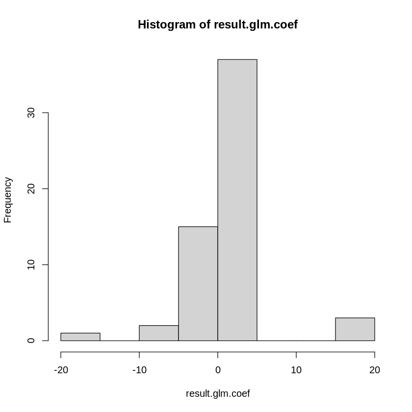

png

```r
names(good.glm)
```

1. ‘ask’
2. ‘azarkansero’
3. ‘back’
4. ‘can’
5. ‘day’
6. ‘depress’
7. ‘feel’
8. ‘friend’
9. ‘genevieveverso’
10. ‘get’
11. ‘got’
12. ‘happi’
13. ‘help’
14. ‘just’
15. ‘life’
16. ‘like’
17. ‘lol’
18. ‘look’
19. ‘love’
20. ‘make’
21. ‘misslusyd’
22. ‘much’
23. ‘need’
24. ‘new’
25. ‘overcom’
26. ‘realli’
27. ‘someon’
28. ‘start’
29. ‘take’
30. ‘talk’
31. ‘thing’
32. ‘think’
33. ‘time’
34. ‘today’
35. ‘treatment’
36. ‘tri’
37. ‘use’
38. ‘via’
39. ‘way’
40. ‘work’

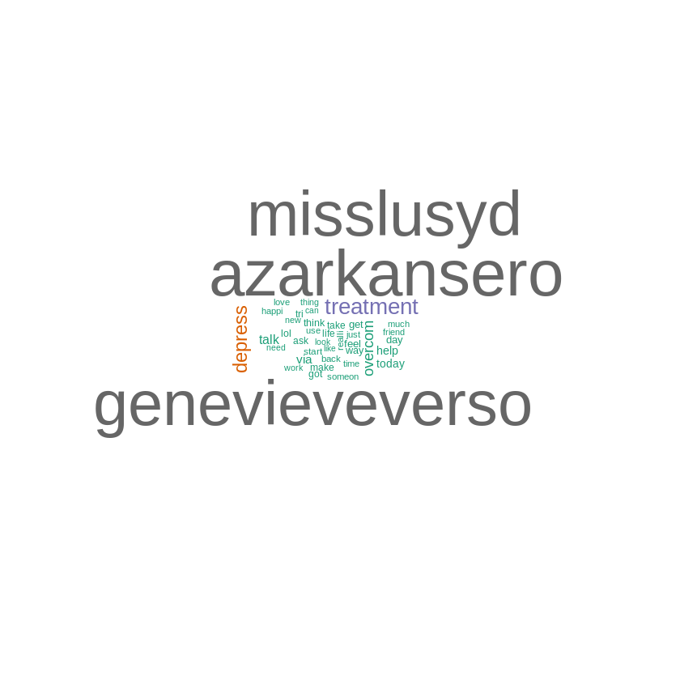

png

```r
cor.special <- brewer.pal(8,"Dark2")  # set up a pretty color scheme
wordcloud(good.word, good.fre,  # make a word cloud
          colors=cor.special,
          ordered.colors=F, min.freq=0)
```

###Negative Wordcloud

```r
bad.glm <- result.glm.coef[which(result.glm.coef < 0)]
# names(bad.glm)[1:50]

cor.special <- brewer.pal(6,"Dark2")
bad.fre <- sort(-bad.glm, decreasing = TRUE)
round(bad.fre, 4)

# hist(as.matrix(bad.fre), breaks=30, col="green")
bad.word <- names(bad.fre)
wordcloud(bad.word, bad.fre,
          color=cor.special, ordered.colors=F, min.freq=0)
```

**now_follow**

16.9185

**realdonaldtrump**

5.3789

**trump**

5.1277

**hey**

1.0291

**man**

0.9385

**god**

0.9227

**hope**

0.5361

**thank**

0.4426

**best**

0.422

**watch**

0.3824

**one**

0.3077

**still**

0.2917

**will**

0.2805

**never**

0.24

**wait**

0.194

**want**

0.1815

**right**

0.1732

**amp**

0.1544

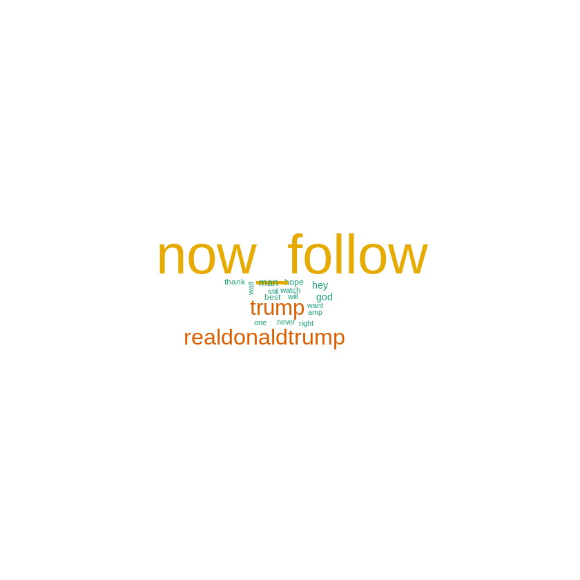

png

###Testing

LASSO Prediction

```r
predict.lasso <- ifelse(predict(result.lasso, as.matrix(data2.test[, -1]), type = "response", s="lambda.1se")>.5, "1", "0")
  # output lasso estimates of prob's
#predict.lasso <- predict(result.lasso, as.matrix(data2.test[, -1]), type = "class", s="lambda.1se")
  # output majority vote labels

# LASSO accuracy
mean(data2.test$label == predict.lasso)   #0.64004914004914; 0.637592137592138 with n-grams
```

0.637592137592138

Relaxed LASSO Prediction

```r
predict.glm <- predict(result.glm, data2.test, type = "response")
class.glm <- ifelse(predict.glm > .5, "1", "0")
# length(class.glm)

testaccuracy.glm <- mean(data2.test$label == class.glm)
testaccuracy.glm   #classification accuracy is 0.643120393120393; 0.640663390663391 with n-grams
```

0.640663390663391

#Text Analysis: Safa Dataset

## 3.4 Bag of Words & Term Frequency

###Corpus: a collection of text - `VCorpus()`: create Volatile Corpus - `inspect()`: display detailed info of a corpus

```r
data.subset <- fread("/content/data/Mental_Health_Twitter_Big.csv", stringsAsFactors = FALSE)
mycorpus1 <- VCorpus(VectorSource(data.subset$post_text))
mycorpus1
typeof(mycorpus1)   ## It is a list
# inspect the first corpus
inspect(mycorpus1[[1]])
# or use `as.character` to extract the text
as.character(mycorpus1[[1]])
```

```
<<VCorpus>>
Metadata:  corpus specific: 0, document level (indexed): 0
Content:  documents: 20000
```

‘list’

```
<<PlainTextDocument>>
Metadata:  7
Content:  chars: 112

The Morning After: The drone that can fly for two hours straight https://t.co/PUvsuAlyLb https://t.co/v1VboCYH4x
```

‘The Morning After: The drone that can fly for two hours straight https://t.co/PUvsuAlyLb https://t.co/v1VboCYH4x’

###Data cleaning using `tm_map()`

```r
# Converts all words to lowercase
mycorpus_clean <- tm_map(mycorpus1, content_transformer(tolower))

# Removes common English stopwords (e.g. "with", "i")
mycorpus_clean <- tm_map(mycorpus_clean, removeWords, stopwords("english"))

# Removes any punctuation
# NOTE: This step may not be appropriate if you want to account for differences
#       on semantics depending on which sentence a word belongs to if you end up
#       using n-grams or k-skip-n-grams.
#       Instead, periods (or semicolons, etc.) can be replaced with a unique
#       token (e.g. "[PERIOD]") that retains this semantic meaning.
mycorpus_clean <- tm_map(mycorpus_clean, removePunctuation)

# Removes numbers
mycorpus_clean <- tm_map(mycorpus_clean, removeNumbers)

# Stem words
mycorpus_clean <- tm_map(mycorpus_clean, stemDocument, lazy = TRUE)
```

###Word frequency matrix

Now we transform each review into a word frequency matrix using the function `DocumentTermMatrix()`.

```r
dtm1 <- DocumentTermMatrix( mycorpus_clean )   ## library = collection of words for all documents
class(dtm1)
inspect(dtm1) # typeof(dtm1)  #length(dimnames(dtm1)$Terms)
```

1. ‘DocumentTermMatrix’
2. ‘simple_triplet_matrix’

```
<<DocumentTermMatrix (documents: 20000, terms: 41861)>>
Non-/sparse entries: 162727/837057273
Sparsity           : 100%
Maximal term length: 140
Weighting          : term frequency (tf)
Sample             :
       Terms
Docs    can get just know like love one peopl think will
  13517   0   0    1    0    1    0   0     0     1    0
  1371    0   0    0    0    0    0   0     0     1    0
  16097   0   0    0    0    0    0   0     0     0    0
  16739   0   0    0    0    0    0   1     0     0    0
  3300    0   0    0    0    0    0   0     0     0    0
  5818    0   0    0    0    0    0   0     0     0    0
  6503    0   0    0    0    0    0   0     1     1    1
  761     0   0    0    0    0    0   0     0     0    0
  7644    0   0    0    0    0    0   0     0     0    2
  8205    0   0    1    0    0    0   0     0     0    0
```

### 3.4.1 Reduce the size of the bag

Many words do not appear nearly as often as others. If your cleaning was done appropriately, it will hopefully not lose much of the information if we drop such rare words. So, we first cut the bag to only include the words appearing at least 1% (or the frequency of your choice) of the time. This reduces the dimension of the features extracted to be analyzed.

```r
threshold <- .01*length(mycorpus_clean)   # 1% of the total documents
words.10 <- findFreqTerms(dtm1, lowfreq=threshold)  # words appearing at least among 1% of the documents
length(words.10)
tail(words.10, n=10)
```

90

1. ‘vote’
2. ‘want’
3. ‘watch’
4. ‘way’
5. ‘well’
6. ‘will’
7. ‘work’
8. ‘yeah’
9. ‘year’
10. ‘yes’

```r
dtm.10<- DocumentTermMatrix(mycorpus_clean, control = list(dictionary = words.10))
dim(as.matrix(dtm.10))
colnames(dtm.10)[40:50]
```

1. 20000
2. 90
1. ‘look’
2. ‘lot’
3. ‘love’
4. ‘made’
5. ‘make’
6. ‘man’
7. ‘mani’
8. ‘mean’
9. ‘much’
10. ‘need’
11. ‘never’

**`removeSparseTerms()`**:

Anther way to reduce the size of the bag is to use `removeSparseTerms`

```r
dtm.10.2 <- removeSparseTerms(dtm1, 1-.01)  # control sparsity < .99
inspect(dtm.10.2)
# colnames(dtm.10.2)[1:50]
# words that are in dtm.10 but not in dtm.10.2
colnames(dtm.10)[!(colnames(dtm.10) %in% colnames(dtm.10.2))]
```

```
<<DocumentTermMatrix (documents: 20000, terms: 87)>>
Non-/sparse entries: 32985/1707015
Sparsity           : 98%
Maximal term length: 6
Weighting          : term frequency (tf)
Sample             :
       Terms
Docs    can get just know like love one peopl think will
  10088   0   7    0    0    0    0   0     0     0    0
  12942   0   3    0    0    0    0   0     0     0    0
  14203   2   1    1    0    1    0   1     1     0    0
  16184   0   0    1    1    0    0   0     0     0    2
  1727    0   0    1    1    4    0   0     1     0    0
  19891   0   0    3    0    2    0   0     0     0    0
  2842    0   0    0    0    1    2   1     2     0    1
  5382    0   0    0    2    1    0   0     0     1    0
  657     0   0    0    0    2    1   0     0     0    1
  7561    0   0    0    1    0    0   0     1     1    0
```

1. ‘’ve’
2. ‘tell’
3. ‘vote’

We end up with two different bags because

- `findFreqTerms()`: counts a word multiple times if it appears multiple times in one document.
- `removeSparseTerms()`: keep words that appear at least once in X% of documents.

### 3.4.2 One step to get `DTM`

We consolidate all possible processing steps to the following clean `R-chunk`, turning texts (input) into `Document Term Frequency` which is a sparse matrix (output) to be used in the down-stream analyses.

All the `tm_map()` can be called inside `DocumentTermMatrix` under parameter called `control`. Here is how.

```r
# Turn texts to corpus
mycorpus1  <- VCorpus(VectorSource(data.subset$post_text))


# Control list for creating our DTM within DocumentTermMatrix
# Can tweak settings based off if you want punctuation, numbers, etc.
control_list <- list( tolower = TRUE,
                      removePunctuation = TRUE,
                      removeNumbers = TRUE,
                      stopwords = stopwords("english"),
                      stemming = TRUE)
# dtm with all terms:
dtm.10.long  <- DocumentTermMatrix(mycorpus1, control = control_list)
#inspect(dtm.10.long)

# kick out rare words
dtm.10<- removeSparseTerms(dtm.10.long, 1-.01)
inspect(dtm.10)

# look at the document 1 before and after cleaning
# inspect(mycorpus1[[1]])
# after cleaning
# colnames(as.matrix(dtm1[1, ]))[which(as.matrix(dtm1[1, ]) != 0)]
```

```
<<DocumentTermMatrix (documents: 20000, terms: 92)>>
Non-/sparse entries: 35148/1804852
Sparsity           : 98%
Maximal term length: 6
Weighting          : term frequency (tf)
Sample             :
       Terms
Docs    can get i’m just know like love one peopl will
  10088   0   7   0    0    0    0    0   0     0    0
  12942   0   3   0    0    0    0    0   0     0    0
  14203   2   1   0    1    0    1    0   1     1    0
  15378   0   0   0    2    0    2    0   0     0    0
  15901   0   0   1    0    0    1    1   0     1    0
  16184   0   0   0    1    1    0    0   0     0    2
  1727    0   0   1    1    1    4    0   0     1    0
  19891   0   0   0    3    0    2    0   0     0    0
  2842    0   0   0    0    0    1    2   1     2    1
  7561    0   0   2    0    1    0    0   0     1    0
```

## 3.5 N-grams

Using the `tm` package along with a custom tokenizer, we can now implement n-grams using R! As is, the tokenizer is set to produce bugrams but you should be able to change this by tweaking the variable `n`.

```r
# The 'n' for n-grams
# n=2 is bi-grams
n <- 2

# Our custom tokenizer
# Uses the ngrams function from the NLP package
# Right now this is for bigrams, but you can change it by changing the value of
# the variable n (includes N-grams for any N <= n)
ngram_tokenizer <- function(x, n) {
  unlist(lapply(ngrams(words(x), 1:n), paste, collapse = "_"), use.names = FALSE)
}
```

We next prepare a clean copus

```r
# Converts all words to lowercase
mycorpus1  <- VCorpus(VectorSource(data.subset$post_text))
mycorpus_clean <- tm_map(mycorpus1, content_transformer(tolower))

# Removes common English stopwords (e.g. "with", "i")
mycorpus_clean <- tm_map(mycorpus_clean, removeWords, stopwords("english"))

# Removes any punctuation
# NOTE: This step may not be appropriate if you want to account for differences
#       on semantics depending on which sentence a word belongs to if you end up
#       using n-grams or k-skip-n-grams.
#       Instead, periods (or semicolons, etc.) can be replaced with a unique
#       token (e.g. "[PERIOD]") that retains this semantic meaning.
mycorpus_clean <- tm_map(mycorpus_clean, removePunctuation)

# Removes numbers
mycorpus_clean <- tm_map(mycorpus_clean, removeNumbers)

# Stem words
mycorpus_clean <- tm_map(mycorpus_clean, stemDocument, lazy = TRUE)
```

Apply the bigram tokenizer to the first review, we see the library or word of bag is enlarged.

```r
inspect(mycorpus_clean[[1]])  # see review 1 again
ngram_tokenizer(mycorpus_clean[[1]], 2) # output bigram of review 1
```

```
<<PlainTextDocument>>
Metadata:  7
Content:  chars: 72

morn drone can fli two hour straight httpstcopuvsualylb httpstcovvbocyhx
```

1. ‘morn’
2. ‘drone’
3. ‘can’
4. ‘fli’
5. ‘two’
6. ‘hour’
7. ‘straight’
8. ‘httpstcopuvsualylb’
9. ‘httpstcovvbocyhx’
10. ‘morn_drone’
11. ‘drone_can’
12. ‘can_fli’
13. ‘fli_two’
14. ‘two_hour’
15. ‘hour_straight’
16. ‘straight_httpstcopuvsualylb’
17. ‘httpstcopuvsualylb_httpstcovvbocyhx’

While we won’t run any analyses with the n-grams, we encourage you to play around with some of the settings to see how the DTM changes, as well as how the analysis might be improved (or worsened) by including the higher order n-grams.

```r
# use ngram_tokenizer()
control_list_ngram <- list(tokenize = function(x) ngram_tokenizer(x, 2))

dtm_ngram <- DocumentTermMatrix(mycorpus_clean, control_list_ngram)
# kick out rare words
dtm_ngram.10 <- removeSparseTerms(dtm_ngram, 1-.01)
inspect(dtm_ngram.10)
```

```
<<DocumentTermMatrix (documents: 20000, terms: 87)>>
Non-/sparse entries: 32985/1707015
Sparsity           : 98%
Maximal term length: 6
Weighting          : term frequency (tf)
Sample             :
       Terms
Docs    can get just know like love one peopl think will
  10088   0   7    0    0    0    0   0     0     0    0
  12942   0   3    0    0    0    0   0     0     0    0
  14203   2   1    1    0    1    0   1     1     0    0
  16184   0   0    1    1    0    0   0     0     0    2
  1727    0   0    1    1    4    0   0     1     0    0
  19891   0   0    3    0    2    0   0     0     0    0
  2842    0   0    0    0    1    2   1     2     0    1
  5382    0   0    0    2    1    0   0     0     1    0
  657     0   0    0    0    2    1   0     0     0    1
  7561    0   0    0    1    0    0   0     1     1    0
```

##Analysis

Once we have turned a text into a vector, we can then apply any methods suitable for the settings. In our case we will use logistic regression models and LASSO to explore the relationship between `label` and `text`.

### 3.5.1 Data preparation

The following chunk output a data frame called data2, combining everything and all the tf’s of each word.

```r
names(data.subset)
# Combine the original data with the text matrix
data1.temp <- data.frame(data.subset,as.matrix(dtm_ngram.10) )
dim(data1.temp)
names(data1.temp)[1:30]
#str(data1.temp)
# data2 consists of date, label and all the top 1% words
data2 <- data1.temp[, -1]
#data2 <- data1.temp
names(data2)[1:20]
dim(data2)  ### remember we have only run 1000 rows

#### We have previously run the entire 100,000 rows and output the DTM out.
### if not, run and write as csv
fwrite(data2, "/content/data/Twitter_tm_freq.csv", row.names = FALSE)
```

1. ‘post_text’
2. ‘label’
1. 20000
2. 89
1. ‘post_text’
2. ‘label’
3. ‘X.re’
4. ‘actual’
5. ‘also’
6. ‘alway’
7. ‘amp’
8. ‘back’
9. ‘bad’
10. ‘best’
11. ‘better’
12. ‘call’
13. ‘can’
14. ‘come’
15. ‘day’
16. ‘don.t’
17. ‘even’
18. ‘feel’
19. ‘first’
20. ‘follow’
21. ‘friend’
22. ‘fuck’
23. ‘game’
24. ‘get’
25. ‘give’
26. ‘gonna’
27. ‘good’
28. ‘got’
29. ‘guy’
30. ‘happi’
1. ‘label’
2. ‘X.re’
3. ‘actual’
4. ‘also’
5. ‘alway’
6. ‘amp’
7. ‘back’
8. ‘bad’
9. ‘best’
10. ‘better’
11. ‘call’
12. ‘can’
13. ‘come’
14. ‘day’
15. ‘don.t’
16. ‘even’
17. ‘feel’
18. ‘first’
19. ‘follow’
20. ‘friend’
1. 20000
2. 88

### 3.5.2 Splitting data

Let’s first read in the processed data with text being a vector.

```r
data2 <- fread("/content/data/Twitter_tm_freq.csv")  #dim(data2)
names(data2)[1:20] # notice that user_id, stars and date are in the data2
dim(data2)
data2$label <- as.factor(data2$label)
table(data2$label)
```

1. ‘label’
2. ‘X.re’
3. ‘actual’
4. ‘also’
5. ‘alway’
6. ‘amp’
7. ‘back’
8. ‘bad’
9. ‘best’
10. ‘better’
11. ‘call’
12. ‘can’
13. ‘come’
14. ‘day’
15. ‘don.t’
16. ‘even’
17. ‘feel’
18. ‘first’
19. ‘follow’
20. ‘friend’
1. 20000
2. 88

```
    0     1
10000 10000
```

As one standard machine learning process, we first split data into two sets one training data and the other testing data. We use training data to build models, choose models etc and make final recommendations. We then report the performance using the testing data.

```r
set.seed(1)  # for the purpose of reporducibility
n <- nrow(data2)
test.index <- sample(n, 0.1*n)
# length(test.index)
data2.test <- data2[test.index, ] # only keep label and the texts
data2.train <- data2[-test.index, ]
dim(data2.train)
```

1. 18000
2. 88

### 3.5.3 Analysis 1: LASSO

We first explore a logistic regression model using LASSO. The following R-chunk runs a LASSO model with $\alpha=.99$. The reason we take an elastic net is to enjoy the nice properties from both `LASSO` (impose sparsity) and `Ridge` (computationally stable).

LASSO takes sparse design matrix as an input. So make sure to extract the sparse matrix first as the input in cv.glm(). It takes about 1 minute to run cv.glm() with sparse matrix or 11 minutes using the regular design matrix.

```
   Length     Class      Mode
       43 character character
```

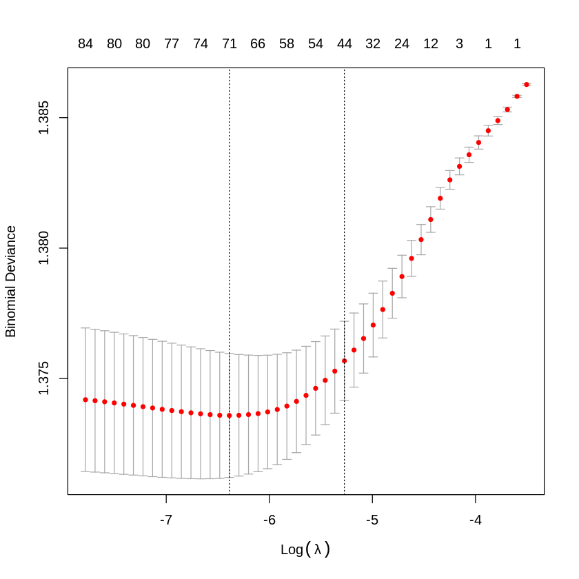

png

```r
### or try `sparse.model.matrix()` which is much faster
y <- data2.train$label
X1 <- sparse.model.matrix(label~., data=data2.train)[, -1]
set.seed(2)
result.lasso <- cv.glmnet(X1, y, alpha=.99, family="binomial")
# 1.25 minutes in my MAC
plot(result.lasso)
# this this may take you long time to run, we save result.lasso
saveRDS(result.lasso, file="data/TextMining_lasso.RDS")
# result.lasso can be assigned back by
# result.lasso <- readRDS("data/TextMining_lasso.RDS")

# number of non-zero words picked up by LASSO when using lambda.1se
coef.1se <- coef(result.lasso, s="lambda.1se")
lasso.words <- coef.1se@Dimnames[[1]] [coef.1se@i][-1] # non-zero variables without intercept.
summary(lasso.words)


# or our old way
#coef.1se <- coef(result.lasso, s="lambda.1se")
#coef.1se <- coef.1se[which(coef.1se !=0),]
#lasso.words <- rownames(as.matrix(coef.1se))[-1]
#summary(lasso.words)



### cv.glmnt with the non-sparse design matrix takes much longer
# X <- as.matrix(data2.train[, -1]) # we can use as.matrix directly her
#### Be careful to run the following LASSO.
#set.seed(2)
#result.lasso <- cv.glmnet(X, y, alpha=.99, family="binomial")
# 10 minutes in my MAC
#plot(result.lasso)
```

### 3.5.4 Analysis 2: Relaxed LASSO

```r
sel_cols <- c("label", lasso.words)
# use all_of() to specify we would like to select variables in sel_cols
data_sub <- data2.train %>% select(all_of(sel_cols))
result.glm <- glm(label~., family=binomial, data_sub) # takes 3.5 minutes
## glm() returns a big object with unnecessary information
# saveRDS(result.glm,
#      file = "data/TextMining_glm.RDS")

## trim the glm() fat from
## https://win-vector.com/2014/05/30/trimming-the-fat-from-glm-models-in-r/
stripGlmLR = function(cm) {
  cm$y = c()
  cm$model = c()

  cm$residuals = c()
  cm$fitted.values = c()
  cm$effects = c()
  cm$qr$qr = c()
  cm$linear.predictors = c()
  cm$weights = c()
  cm$prior.weights = c()
  cm$data = c()


  cm$family$variance = c()
  cm$family$dev.resids = c()
  cm$family$aic = c()
  cm$family$validmu = c()
  cm$family$simulate = c()
  attr(cm$terms,".Environment") = c()
  attr(cm$formula,".Environment") = c()

  cm
}

#result.glm.small <- stripGlmLR(result.glm)
result.glm.small <- result.glm

saveRDS(result.glm.small,
     file = "/content/data/TextMining_glm_small.RDS")
```

```r
View(result.glm.small)
```

```
Call:  glm(formula = label ~ ., family = binomial, data = data_sub)

Coefficients:
(Intercept)         X.re        alway         back         best       better
  -0.007658     0.298520    -0.074021    -0.079673    -0.016224    -0.238516
        day         even        first       follow       friend         fuck
   0.112720    -0.062677    -0.007669    -0.203323     0.467575     0.520260
       game         give        gonna          got        happi         hope
  -0.437904     0.101845     0.285431     0.030097    -0.162106    -0.003150
        let         life         like          lol          lot          man
  -0.206311     0.383762     0.135270     0.110871    -0.074033    -0.099732
       mani         mean         much        never          one       person
  -0.408640     0.258361     0.293571    -0.050012    -0.061801     0.053222
      pleas         read         shit        start        still         sure
  -0.118377    -0.193374    -0.153857    -0.095358     0.145200    -0.211362
       take        thank          tri          use          way         well
  -0.165191     0.017140     0.101179     0.016646     0.014820    -0.213817
       work         yeah
   0.030768    -0.293026

Degrees of Freedom: 17999 Total (i.e. Null);  17956 Residual
Null Deviance:      24950
Residual Deviance: 24810    AIC: 24900
```

### 3.5.5 Analysis 3: Word cloud! (Sentiment analysis)

TIME TO PLOT A WORD CLOUD!! Plot the world clouds, the size of the words are prop to the logistic reg coef’s

```r
result.glm <- readRDS("data/TextMining_glm_small.RDS")
result.glm.coef <- coef(result.glm)[-1]  # took intercept out
hist(result.glm.coef)

# pick up the positive coef's which are positively related to the prob of being depressed
good.glm <- result.glm.coef[which(result.glm.coef > 0)]
good.glm <- good.glm
names(good.glm)  # which words are positively associated with depression

good.fre <- sort(good.glm, decreasing = TRUE) # sort the coef's
round(good.fre, 4) # leading 20 positive words, amazing!
length(good.fre)  # 390 good words

# hist(as.matrix(good.fre), breaks=30, col="red")
good.word <- names(good.fre)  # good words with a decreasing order in the coeff's
```

1. ‘X.re’
2. ‘day’
3. ‘friend’
4. ‘fuck’
5. ‘give’
6. ‘gonna’
7. ‘got’
8. ‘life’
9. ‘like’
10. ‘lol’
11. ‘mean’
12. ‘much’
13. ‘person’
14. ‘still’
15. ‘thank’
16. ‘tri’
17. ‘use’
18. ‘way’
19. ‘work’

**fuck**

0.5203

**friend**

0.4676

**life**

0.3838

**X.re**

0.2985

**much**

0.2936

**gonna**

0.2854

**mean**

0.2584

**still**

0.1452

**like**

0.1353

**day**

0.1127

**lol**

0.1109

**give**

0.1018

**tri**

0.1012

**person**

0.0532

**work**

0.0308

**got**

0.0301

**thank**

0.0171

**use**

0.0166

**way**

0.0148

19

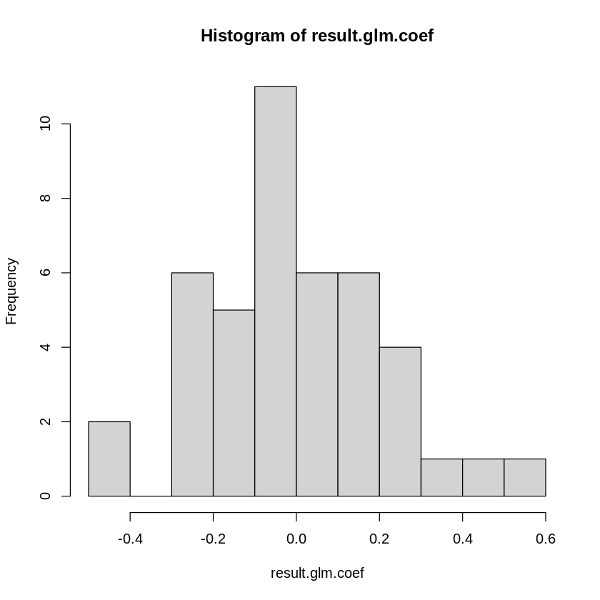

png

```r
names(good.glm)
```

1. ‘X.re’
2. ‘day’
3. ‘friend’
4. ‘fuck’
5. ‘give’
6. ‘gonna’
7. ‘got’
8. ‘life’
9. ‘like’
10. ‘lol’
11. ‘mean’
12. ‘much’
13. ‘person’
14. ‘still’
15. ‘thank’
16. ‘tri’
17. ‘use’
18. ‘way’
19. ‘work’

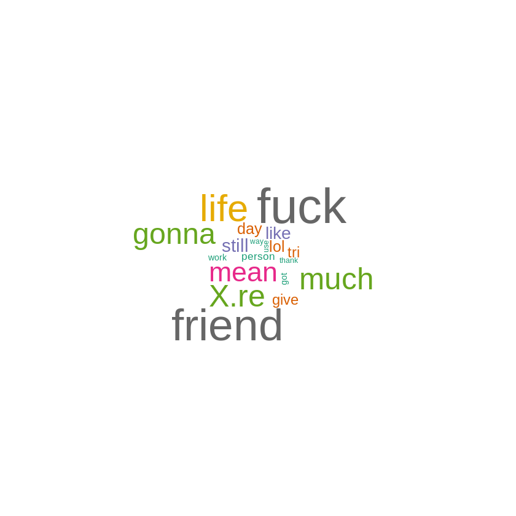

png

```r
cor.special <- brewer.pal(8,"Dark2")  # set up a pretty color scheme
wordcloud(good.word, good.fre,  # make a word cloud
          colors=cor.special,
          ordered.colors=F, min.freq=0)
```

###Negative Wordcloud

```r
bad.glm <- result.glm.coef[which(result.glm.coef < 0)]
# names(bad.glm)[1:50]

cor.special <- brewer.pal(6,"Dark2")
bad.fre <- sort(-bad.glm, decreasing = TRUE)
round(bad.fre, 4)

# hist(as.matrix(bad.fre), breaks=30, col="green")
bad.word <- names(bad.fre)
wordcloud(bad.word, bad.fre,
          color=cor.special, ordered.colors=F, min.freq=0)
```

**game**

0.4379

**mani**

0.4086

**yeah**

0.293

**better**

0.2385

**well**

0.2138

**sure**

0.2114

**let**

0.2063

**follow**

0.2033

**read**

0.1934

**take**

0.1652

**happi**

0.1621

**shit**

0.1539

**pleas**

0.1184

**man**

0.0997

**start**

0.0954

**back**

0.0797

**lot**

0.074

**alway**

0.074

**even**

0.0627

**one**

0.0618

**never**

0.05

**best**

0.0162

**first**

0.0077

**hope**

0.0031

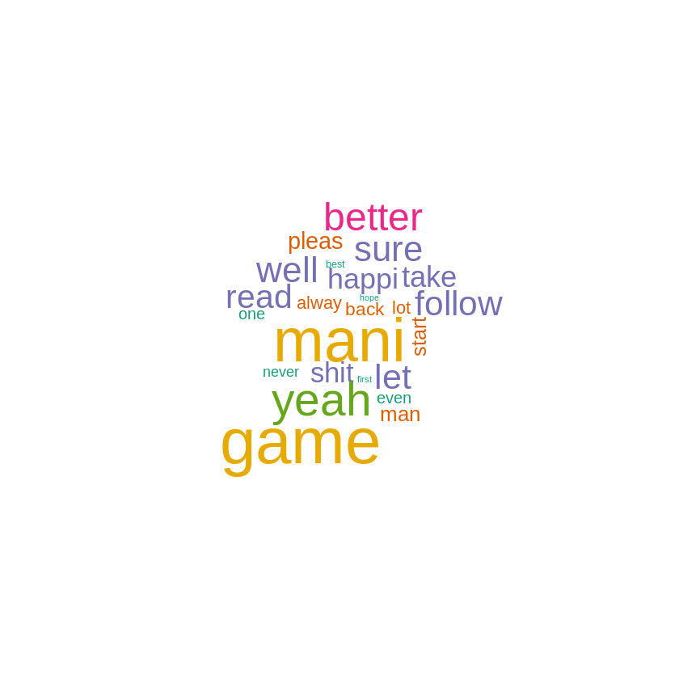

png

###Testing

LASSO Prediction

```r
predict.lasso <- ifelse(predict(result.lasso, as.matrix(data2.test[, -1]), type = "response", s="lambda.1se")>.5, "1", "0")
  # output lasso estimates of prob's
#predict.lasso <- predict(result.lasso, as.matrix(data2.test[, -1]), type = "class", s="lambda.1se")
  # output majority vote labels

# LASSO accuracy
mean(data2.test$label == predict.lasso)   #0.5425; 0.5405 with n-grams
```

0.5405

Relaxed LASSO Prediction

```r
predict.glm <- predict(result.glm, data2.test, type = "response")
class.glm <- ifelse(predict.glm > .5, "1", "0")
# length(class.glm)

testerror.glm <- mean(data2.test$label == class.glm)
testerror.glm   #classification accuracy is 0.5305; 0.534 with n-grams
```

0.534